# R Notebook

### Isabel Metzger Machine Learning HW 2 PART B

B. Linear regression Choose your favorite biomedical dataset and perform linear regression to predict a  
variable of interest. Briefly describe your data. Think and answer the following questions: • Use simple linear regression. How well does your model perform? How did you choose  
the predictor variable?

• Use multiple linear regression. Do all the predictor variables you use contribute to the  
prediction? How well does the model fit the data? Is it better than if you had a simple  
linear regression model for every individual variable?

## The data

This Data is the Pima Indians Diabetes set, which has 768 obs. of 9 variables.

pregnant: Number of times pregnant glucose: Plasma glucose concentration (glucose tolerance test) pressure: Diastolic blood pressure (mm Hg) triceps: Triceps skin fold thickness (mm) insulin: 2-Hour serum insulin (mu U/ml) mass: Body mass index (weight in kg/(height in meters squared) pedigree: Diabetes pedigree function age: Age (years) diabetes: Class variable (test for diabetes) This hw assignment will be on linear regression, trying to predict a numerical variable from another numerical variable.

```r
?PimaIndiansDiabetes
```

```r
library(tidyverse)
library(ggplot2)
library(ggthemes)
library(mlbench)
data("PimaIndiansDiabetes")
PimaIndiansDiabetes %>% str()
```

```
'data.frame':   768 obs. of  9 variables:
 $ pregnant: num  6 1 8 1 0 5 3 10 2 8 ...
 $ glucose : num  148 85 183 89 137 116 78 115 197 125 ...
 $ pressure: num  72 66 64 66 40 74 50 0 70 96 ...
 $ triceps : num  35 29 0 23 35 0 32 0 45 0 ...
 $ insulin : num  0 0 0 94 168 0 88 0 543 0 ...
 $ mass    : num  33.6 26.6 23.3 28.1 43.1 25.6 31 35.3 30.5 0 ...
 $ pedigree: num  0.627 0.351 0.672 0.167 2.288 ...
 $ age     : num  50 31 32 21 33 30 26 29 53 54 ...
 $ diabetes: Factor w/ 2 levels "neg","pos": 2 1 2 1 2 1 2 1 2 2 ...
```

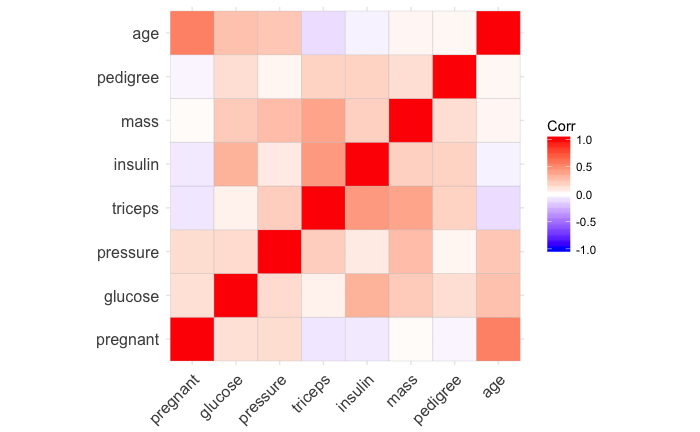

```r
numeric_PimaIndiansDiabetes <- PimaIndiansDiabetes %>% select(-diabetes)
scaled_matrix <- scale(numeric_PimaIndiansDiabetes)
# because the dataset has different variables scaling may help
ggcorrplot::ggcorrplot(cor(scaled_matrix), method=c("square"))
```

Interested in predicting insulin using simple linear regression:

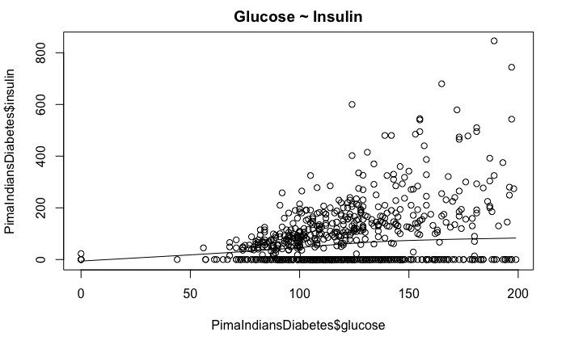

```r
scaled_df <- as.data.frame(scaled_matrix)
scatter.smooth(x=PimaIndiansDiabetes$glucose, y=PimaIndiansDiabetes$insulin, main="Glucose ~ Insulin")
```

We can see that because there are instances when insulin == 0, the linear fit does not seem to be best.

However, we can look into this by looking at outliers:

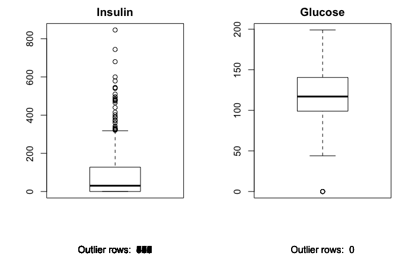

```r
par(mfrow=c(1, 2))  # divide graph area in 2 columns
boxplot(PimaIndiansDiabetes$insulin, main="Insulin", sub=paste("Outlier rows: ", boxplot.stats(PimaIndiansDiabetes$insulin)$out))  # box plot for 'speed'
boxplot(PimaIndiansDiabetes$glucose, main="Glucose", sub=paste("Outlier rows: ", boxplot.stats(PimaIndiansDiabetes$glucose)$out))  # box plot for 'distance'
```

What we see is a large number of outliers in the insulin data.

```r
library(e1071)
par(mfrow=c(1, 2))
plot(density(PimaIndiansDiabetes$insulin), main="Density Plot: Insulin", ylab="Frequency", sub=paste("Skewness:", round(e1071::skewness(PimaIndiansDiabetes$insulin), 2)))  # density plot for 'insulin'
polygon(density(cars$speed), col="red")
```

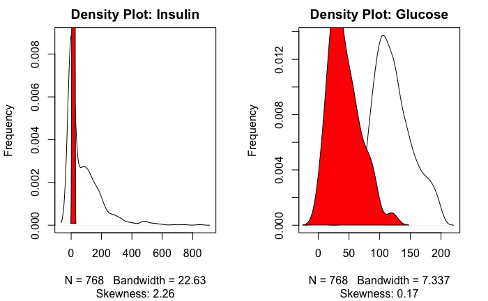

```r
plot(density(PimaIndiansDiabetes$glucose), main="Density Plot: Glucose", ylab="Frequency", sub=paste("Skewness:", round(e1071::skewness(PimaIndiansDiabetes$glucose), 2)))
polygon(density(cars$dist), col="red")
```

```r
cor(PimaIndiansDiabetes$glucose, PimaIndiansDiabetes$insulin) #0.3313571
```

```
[1] 0.3313571
```

This number is very low, already indicating that a linear model may not be the perfect fit. ### OLS regression

```r
fit1 <- lm(insulin ~ glucose, data=PimaIndiansDiabetes)  # build linear regression model on full data
print(fit1)
```

```
Call:
lm(formula = insulin ~ glucose, data = PimaIndiansDiabetes)

Coefficients:
(Intercept)      glucose
    -64.593        1.194
```

The formula indicates insulin = 1.194(glucose) - 64.593

```r
summary(fit1)
```

```
Call:
lm(formula = insulin ~ glucose, data = PimaIndiansDiabetes)

Residuals:
    Min      1Q  Median      3Q     Max
-173.09  -71.86  -20.21   45.93  684.86

Coefficients:
            Estimate Std. Error t value Pr(>|t|)
(Intercept) -64.5925    15.3652  -4.204 2.93e-05 ***
glucose       1.1944     0.1229   9.720  < 2e-16 ***
---
Signif. codes:  0 ‘***’ 0.001 ‘**’ 0.01 ‘*’ 0.05 ‘.’ 0.1 ‘ ’ 1

Residual standard error: 108.8 on 766 degrees of freedom
Multiple R-squared:  0.1098,    Adjusted R-squared:  0.1086
F-statistic: 94.48 on 1 and 766 DF,  p-value: < 2.2e-16
```

```r
modelSummary1 <- summary(fit1)  # capture model summary as an object
modelCoeffs1 <- modelSummary1$coefficients  # model coefficients
beta.estimate1 <- modelCoeffs1["glucose", "Estimate"]  # get beta estimate for speed
std.error1 <- modelCoeffs1["glucose", "Std. Error"]  # get std.error for speed
t_value1 <- beta.estimate1/std.error1  # calc t statistic
p_value1 <- 2*pt(-abs(t_value1), df=nrow(PimaIndiansDiabetes)-ncol(PimaIndiansDiabetes))  # calc p Value
f_statistic <- fit1$fstatistic[1]  # fstatistic
f <- summary(fit1)$fstatistic  # parameters for model p-value calc
model_p <- pf(f[1], f[2], f[3], lower=FALSE)
t_value1
```

```
[1] 9.72
```

```r
p_value1
```

```
[1] 3.974861e-21
```

```r
AIC(fit1)  # 9386.637
```

```
[1] 9386.637
```

```r
BIC(fit1)  # 400.568
```

```
[1] 9400.568
```

```r
model_p
```

```
       value
3.882624e-21
```

For a pvalue less than 0.05 (such as the one in our case), the t-value should be above 1.96.

Although the fit does not look perfectly linear, there is indication that glucose and insulin are correlated. Building the linear model with the training data.

Another thing to note is the low R squared value. A typical “good R squared value” would be above 0.70. This model performs poorly with an R squared value of 0.1098.

Building the model

```r
set.seed(42)
# using a 70 percent to 30 percent splot
train_faction <- 0.7
df <- PimaIndiansDiabetes
train_ind <- sample(nrow(df),round(train_faction*nrow(df)))
train_set <- df[train_ind,]
test_set <- df[-train_ind,]
```

```r
lmMod <- lm(insulin ~ glucose, data=train_set)  # build the model
insPred <- predict(lmMod, test_set)
summary(lmMod)
```

```
Call:
lm(formula = insulin ~ glucose, data = train_set)

Residuals:
    Min      1Q  Median      3Q     Max
-179.30  -74.40  -16.89   43.09  679.18

Coefficients:
            Estimate Std. Error t value Pr(>|t|)
(Intercept) -69.2138    18.7763  -3.686 0.000251 ***
glucose       1.2488     0.1498   8.336 6.52e-16 ***
---
Signif. codes:  0 ‘***’ 0.001 ‘**’ 0.01 ‘*’ 0.05 ‘.’ 0.1 ‘ ’ 1

Residual standard error: 114.4 on 536 degrees of freedom
Multiple R-squared:  0.1148,    Adjusted R-squared:  0.1131
F-statistic: 69.48 on 1 and 536 DF,  p-value: 6.521e-16
```

The p value for the model is significant, but the Rsquared still remains low. Hopefully the linear model can be improved by using other variables in the data. The R squared indicates that about 11 % of the variance is explained by this model.

```r
actuals_preds <- data.frame(cbind(actuals=test_set$insulin, predicteds=insPred))  # make actuals_predicteds dataframe.
correlation_accuracy <- cor(actuals_preds)  # 82.7%
head(actuals_preds)
```

|  | actuals | predicteds |
| --- | --- | --- |
| 4 | 94 | 41.93261 |
| 5 | 168 | 101.87674 |
| 7 | 88 | 28.19542 |
| 11 | 0 | 68.15817 |
| 13 | 0 | 104.37441 |
| 17 | 230 | 78.14885 |

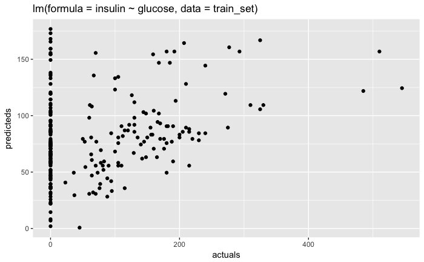

```r
actuals_preds %>% ggplot(aes(actuals, predicteds)) + geom_point() + ggtitle("lm(formula = insulin ~ glucose, data = train_set)")
```

We can see a huge discrepency due to the actual insulin values that are at 0. When exploring this model, I may filter any insulin values that are very low.

```r
min_max_accuracy <- mean(apply(actuals_preds, 1, min) / apply(actuals_preds, 1, max))
min_max_accuracy # 0.2850993
```

```
[1] 0.2850993
```

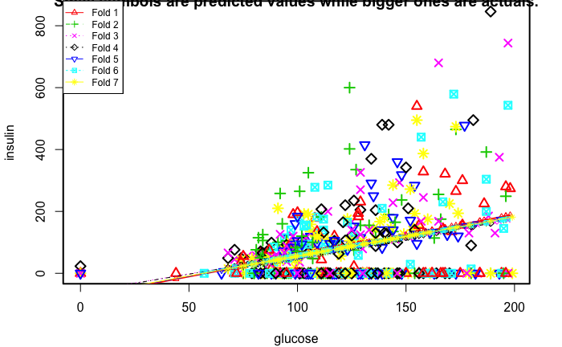

```r
library(DAAG)
cvResults <- suppressWarnings(CVlm(data=train_set, form.lm=insulin ~ glucose, m=7, dots=FALSE, seed=42, legend.pos="topleft",  printit=FALSE, main="Small symbols are predicted values while bigger ones are actuals.")) # performs the CV
```

```r
attr(cvResults, 'ms')  # 13107.95
```

```
[1] 13107.95
```

The mean squared error is 13107.95 which is very high. This should be as low as possible.

### multiple linear model

Hopefully, the multiple linear model will show an increase in the model’s accuracy and other important statistics.

```r
multiple_model <- lm(insulin ~ . , data = train_set)
selectedMod <- step(multiple_model)
```

```
Start:  AIC=5007.65
insulin ~ pregnant + glucose + pressure + triceps + mass + pedigree +
    age + diabetes

           Df Sum of Sq     RSS    AIC
- mass      1      4811 5740942 5006.1
- age       1      5541 5741673 5006.2
- pregnant  1      9033 5745164 5006.5
- diabetes  1     15728 5751859 5007.1
- pressure  1     17512 5753644 5007.3
- pedigree  1     20727 5756858 5007.6
<none>                  5736131 5007.6
- glucose   1    755681 6491813 5072.2
- triceps   1    966774 6702906 5089.4

Step:  AIC=5006.1
insulin ~ pregnant + glucose + pressure + triceps + pedigree +
    age + diabetes

           Df Sum of Sq     RSS    AIC
- age       1      4871 5745813 5004.6
- pregnant  1      9053 5749995 5004.9
- pedigree  1     20218 5761160 5006.0
- diabetes  1     21089 5762031 5006.1
<none>                  5740942 5006.1
- pressure  1     21667 5762609 5006.1
- glucose   1    751301 6492243 5070.3
- triceps   1   1030468 6771410 5092.9

Step:  AIC=5004.55
insulin ~ pregnant + glucose + pressure + triceps + pedigree +
    diabetes

           Df Sum of Sq     RSS    AIC
- pedigree  1     18999 5764812 5004.3
<none>                  5745813 5004.6
- pregnant  1     21493 5767307 5004.6
- diabetes  1     22896 5768709 5004.7
- pressure  1     27228 5773042 5005.1
- glucose   1    750804 6496617 5068.6
- triceps   1   1061159 6806972 5093.7

Step:  AIC=5004.33
insulin ~ pregnant + glucose + pressure + triceps + diabetes

           Df Sum of Sq     RSS    AIC
- diabetes  1     20060 5784872 5004.2
<none>                  5764812 5004.3
- pregnant  1     23422 5788233 5004.5
- pressure  1     28520 5793331 5005.0
- glucose   1    784290 6549102 5071.0
- triceps   1   1151154 6915966 5100.3

Step:  AIC=5004.2
insulin ~ pregnant + glucose + pressure + triceps

           Df Sum of Sq     RSS    AIC
<none>                  5784872 5004.2
- pressure  1     26230 5811103 5004.6
- pregnant  1     34715 5819587 5005.4
- glucose   1    874751 6659623 5078.0
- triceps   1   1133329 6918201 5098.5
```

```r
summary(selectedMod)
```

```
Call:
lm(formula = insulin ~ pregnant + glucose + pressure + triceps,
    data = train_set)

Residuals:
    Min      1Q  Median      3Q     Max
-415.43  -55.93  -11.30   29.44  661.69

Coefficients:
            Estimate Std. Error t value Pr(>|t|)
(Intercept) -95.4455    21.9707  -4.344 1.67e-05 ***
pregnant     -2.4215     1.3540  -1.788   0.0743 .
glucose       1.2489     0.1391   8.978  < 2e-16 ***
pressure     -0.3776     0.2429  -1.555   0.1206
triceps       2.9911     0.2927  10.219  < 2e-16 ***
---
Signif. codes:  0 ‘***’ 0.001 ‘**’ 0.01 ‘*’ 0.05 ‘.’ 0.1 ‘ ’ 1

Residual standard error: 104.2 on 533 degrees of freedom
Multiple R-squared:  0.2695,    Adjusted R-squared:  0.264
F-statistic: 49.16 on 4 and 533 DF,  p-value: < 2.2e-16
```

```r
selectedMod
```

```
Call:
lm(formula = insulin ~ pregnant + glucose + pressure + triceps,
    data = train_set)

Coefficients:
(Intercept)     pregnant      glucose     pressure      triceps
   -95.4455      -2.4215       1.2489      -0.3776       2.9911
```

SelectMod performed the best. It used the variables pregnant, glucose, pressure and triceps.

Surprisingly, the model did not use pedigree or if the patient was diagnosed with diabetes.

```r
summary(selectedMod)
```

```
Call:
lm(formula = insulin ~ pregnant + glucose + pressure + triceps,
    data = train_set)

Residuals:
    Min      1Q  Median      3Q     Max
-415.43  -55.93  -11.30   29.44  661.69

Coefficients:
            Estimate Std. Error t value Pr(>|t|)
(Intercept) -95.4455    21.9707  -4.344 1.67e-05 ***
pregnant     -2.4215     1.3540  -1.788   0.0743 .
glucose       1.2489     0.1391   8.978  < 2e-16 ***
pressure     -0.3776     0.2429  -1.555   0.1206
triceps       2.9911     0.2927  10.219  < 2e-16 ***
---
Signif. codes:  0 ‘***’ 0.001 ‘**’ 0.01 ‘*’ 0.05 ‘.’ 0.1 ‘ ’ 1

Residual standard error: 104.2 on 533 degrees of freedom
Multiple R-squared:  0.2695,    Adjusted R-squared:  0.264
F-statistic: 49.16 on 4 and 533 DF,  p-value: < 2.2e-16
```

p-value: < 2.2e-16 indicating significance The R-squared indicates that %27 percent of the variance is explained by this model.

```r
car::vif(selectedMod)
```

```
pregnant  glucose pressure  triceps
1.041448 1.038967 1.092434 1.064542
```

```r
pred_multimodel <- predict(selectedMod, test_set)
head(pred_multimodel)
```

```
        4         5         7        11        13        17
 57.15552 165.23489  71.53631  -2.49528  23.72484 160.78333
```

```r
actuals_preds_multifit <- data.frame(cbind(actuals=test_set$insulin, predicteds=pred_multimodel))  # make actuals_predicteds dataframe.
correlation_accuracy <- cor(actuals_preds_multifit)  # 82.7%
head(actuals_preds_multifit)
```

|  | actuals | predicteds |
| --- | --- | --- |
| 4 | 94 | 57.15552 |
| 5 | 168 | 165.23489 |
| 7 | 88 | 71.53631 |
| 11 | 0 | -2.49528 |
| 13 | 0 | 23.72484 |
| 17 | 230 | 160.78333 |

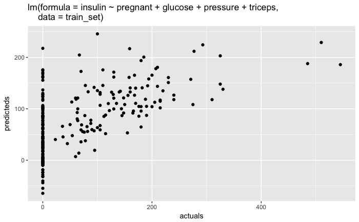

```r
actuals_preds_multifit %>% ggplot(aes(actuals, predicteds)) + geom_point() + ggtitle("lm(formula = insulin ~ pregnant + glucose + pressure + triceps,
    data = train_set)")
```

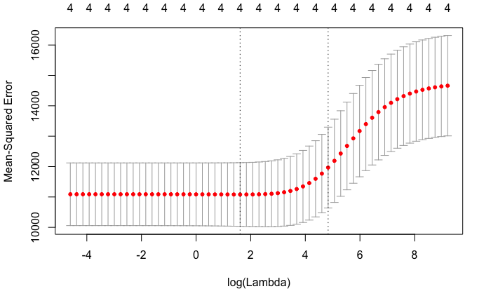

```r
library(broom)
library(glmnet)
y <- train_set$insulin
# selecting x to have what we have decided as the selected model above
x <- train_set %>% select(pregnant, glucose, pressure, triceps) %>% data.matrix()
lambdas =  10^seq(4, -2, by = -.1)  # chose 4 for the 4 predictive variables
cv_fit <- cv.glmnet(x, y, alpha = 0, lambda = lambdas)  # alpha set to 0 is for ridge regression
plot(cv_fit)
```

```r
summary(cv_fit)
```

```
           Length Class  Mode
lambda     61     -none- numeric
cvm        61     -none- numeric
cvsd       61     -none- numeric
cvup       61     -none- numeric
cvlo       61     -none- numeric
nzero      61     -none- numeric
name        1     -none- character
glmnet.fit 12     elnet  list
lambda.min  1     -none- numeric
lambda.1se  1     -none- numeric
```

```r
cv_fit$lambda.min
```

```
[1] 5.011872
```

The lambda min that showed the best fit for this type of model is 5.011872.

```r
ridge.fit <- cv_fit$glmnet.fit
x_test <- test_set %>% select(pregnant, glucose, pressure, triceps) %>% data.matrix()
predictions_ridge <- predict(ridge.fit, s = 5.011872, x_test)
```

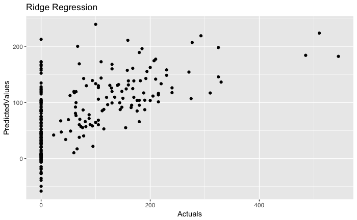

```r
actuals_preds_ridgemodel <- data.frame(cbind(actuals=test_set$insulin, predictions_ridge))
correlation_accuracy_ridgemodel <- cor(actuals_preds_ridgemodel)
names(actuals_preds_ridgemodel) <- c("Actuals", "PredictedValues")
actuals_preds_ridgemodel %>% ggplot(aes(Actuals, PredictedValues)) + geom_point() + ggtitle("Ridge Regression")
```

```r
rsquared.ridgemodel <- 1 - sum((actuals_preds_ridgemodel$PredictedValues-actuals_preds_ridgemodel$Actuals)^2) / sum((actuals_preds_ridgemodel$Actuals-mean(actuals_preds_ridgemodel$Actuals))^2)
rsquared.ridgemodel
```

```
[1] 0.3665032
```

0.3665032 indicating that %36 percent of the variance is explained by this model.

### Conclusion:

These models may not be the best fit for this data. However, we can see that although all show statistical significance. The first linear model, which only used glucose and insulin performed the worst. The second model, which included multiple variables, performed better, and lastly the ridge model had the highest Rsquared and performed the best out of the three.